# R and Databases

August 30, 2018

## The Database

- *What is a Database?*
  - An organized form of information.
- *What is a Relational Database Management System (RBDMS)?*
  - Proprietary or open source software designed to maintain and manage structured data
  - Data is stored in tables of rows and columns within an interconnected system of relational keys (primary/foreign IDs)
  - Relational model based on IBM's Edgar F. Codd's 1970 paper, ["A Relational Model of Data for Large Shared Data Banks"](http://www.seas.upenn.edu/~zives/03f/cis550/codd.pdf)

## Database Schema - Simple

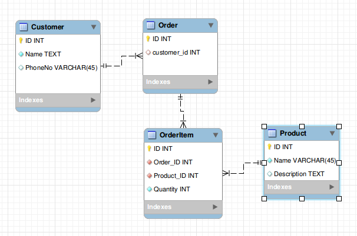

## Database Schema - Moderate

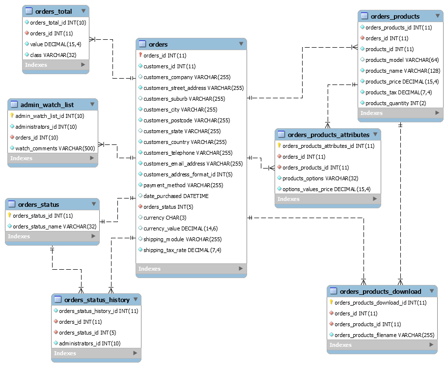

## Database Schema - Moderate

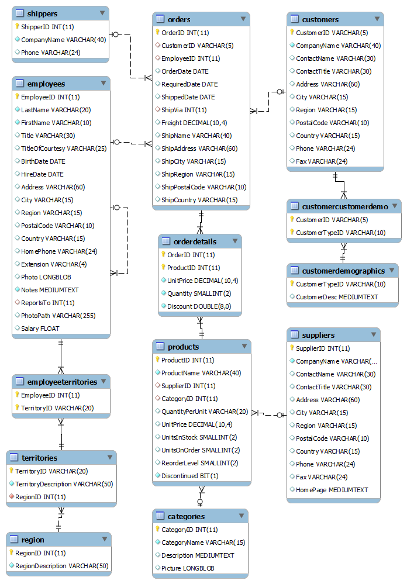

## Database Schema - Complex

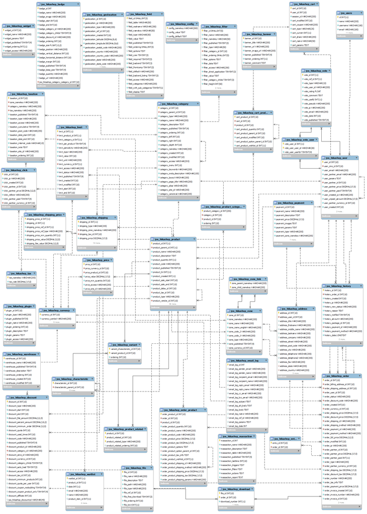

## Postgres Architecture

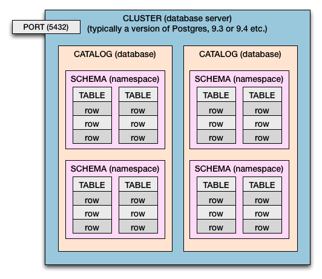

## Why use a Database?

- Data persistence: historical and current needs
- Maintenance/hygiene: adherence to types with less munging/cleaning
- Storage efficiency: normalization reduces repetition of data
- Centralization: multiple user environment and security
- Scalability: not limited to local resources

## What is SQL?

- A special purpose, declarative language designed to define and manage database objects that interact with data
- Initially developed by IBM's Chamberlin and Boyce
  - Inspired by Codd's relational model: [Early History of SQL](https://ieeexplore.ieee.org/stamp/stamp.jsp?reload=true&tp=&arnumber=6359709)
  - Rooted in relational algebra but in a readable form free from mathematical concepts
- Being declarative (non-procedural), SQL does not detail how processing is to be done but passes commands to the optimizing compiler

## Typical SQL

– UNIT LEVEL QUERY

```
    SELECT column1, column2, column3
    FROM table1 t1.
    INNER JOIN table2 t2 ON t1.matchcolumn = t2.matchcolumn
    WHERE column1 = condition1
    ORDER BY column1, column2
```

– AGGREGATE QUERY

```
    SELECT column1, column2, SUM(column3) As Sum_of_Column3
    FROM table1
    INNER JOIN table2 t2 ON t1.matchcolumn = t2.matchcolumn
    WHERE column1 = condition
    GROUP column1, column2
    HAVING SUM(column3) = condition
    ORDER BY column1, column2, SUM(column3) DESC
```

## Major RDBMS

[figure not shown]

- Proprietary
  - Oracle: first commercially successful RDBMS, 1979
  - SQL Server: began as a Sybase project
  - DB2: began exclusively on main frames
  - Others: MS Access, Teradata, SAP
- Open Source
  - PostgreSQL: advanced level object-oriented RDBMS
  - MySQL: popular in web development, part of LAMP stack
  - SQLite: file-level RDBMS, among most used in world
  - NoSQL: MongoDB, Cassandra, Couchbase

## Database Humor

*A big party is being held to honor relational database systems and their impact on modern society. Outside the venue, the host awaits the guests.*

The first limousine arrives and out steps Oracle followed by 4 people.

- Host: Who have you brought along?
- Oracle: I have 4 DBA's in tow. One to install me, one to design the databases, one to administer me, and the other to justify the cost.

A second limo arrives and out steps DB2 followed by 40 people.

- Host: Who have you bought along?
- DB2: I have 2 DBA's, 2 hardware specialists, and 36 consultants.

## Database Humor

A third limo arrives and out steps SQL Server all on his own.

- Host: Why haven't you brought anyone?
- SQL Server: I didn't bring anyone because I am easy to install and am basically self managing. But I did bring the #sqlhelp Twitter hashtag for when the excrement hits the fan.

20 minutes later, up rushes MySQL, unshaved, hair a mess.

- Host: Where have you been MySQL?
- MySQL: Sorry, I thought it was February 31st.

## Programming Interfaces

[figure not shown]

- Most programming languages support RDBMS connections
- Some languages maintain consistent DB-API specifications and standards:
  - Java: JDBC
  - C++: SQLAPI++
  - NET: ODBC/OLEDB
  - PHP: PDO
  - Python: PEP 249
  - Perl, Ruby, R: DBI

## R DB-APIs

- General: RJDBC, RODBC, odbc
- Specific:
  - DBI standard - ROracle, RPostgreSQL, RMySQL, RSQLite
  - Standalone - ibmdbr, mssqlr

| Capability | SQL Command | R DBI Command |
| --- | --- | --- |
| Import data | `SELECT` | `dbGetQuery()` |
| Run actions | `ALTER`, `UPDATE`, `DELETE`, `EXECUTE` | `dbSendQuery()` |
| Export data | `DROP`, `CREATE`, `INSERT` | `dbWriteTable()` |

## RPostgreSQL API

- Began in 2008 Google Summer of Code by Sameer Kuma Prayaga
- Developers: Sameer Kumar Prayaga, Joe Conway, Neil Tiffin, Dirk Eddelbuettel
- Lead Maintainer: Tomoaki Nishiyama on [Github](https://github.com/tomoakin/RPostgreSQL)
- Highlights: implemented all DBI features, transaction support, type mapping for dates/timestamps
- Others: RPostgres, rpg, rpgsql, Postgres+GIS

## Best Practices

- Credentials: use configuration files to avoid exposure
- Parameterization: readability, avoid SQL injection, abstracts data and code
- Business Logic: use stored procedures over application layer code (R)
- Client/Server Jobs: build schemas and objects on server, process data on client (R)

[figure not shown]

## Meetup Speakers

**Gene L**: Co-organizer and Data Scientist at City Of Chicago  
*Lessons Learned in Transitioning Oracle to Postgres*

[figure not shown]

**Adam D**: PhD student at University of Chicago, Department of Computer Science  
*Configurability and Features of Postgres 10*